# Exploring housing demand

2026-07-21

The purpose of this memo is to explore the concept of housing demand in DC. There are three parts:

- Descriptive statistics about DC’s historical & current population
- Population extrapolations to 2030
- Next steps

## DC’s historical population

After 1950, the District’s population sank, as tens of thousands of mostly-white residents relocated to the suburbs.

Starting around 2000, this decades-long downward trend reversed, although the COVID pandemic knocked back DC’s population growth again, at least temporarily.

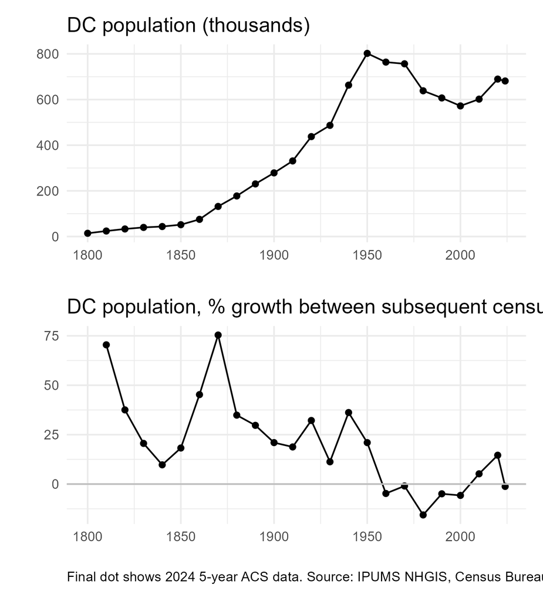

## Extrapolations to 2030

A few potential futures are charted below:

- The highest-growth scenario: Janeese Lewis-George’s 72,000 housing unit goal achieved by 2030, and ~all of those units are filled.
- A high-growth scenario: Population grows at average annual rate observed during 2012-2020 period.
- A trend growth scenario: Population increases linearly after 2023-2024.
- A pessimistic scenario: Population declines at 0.1%/year.

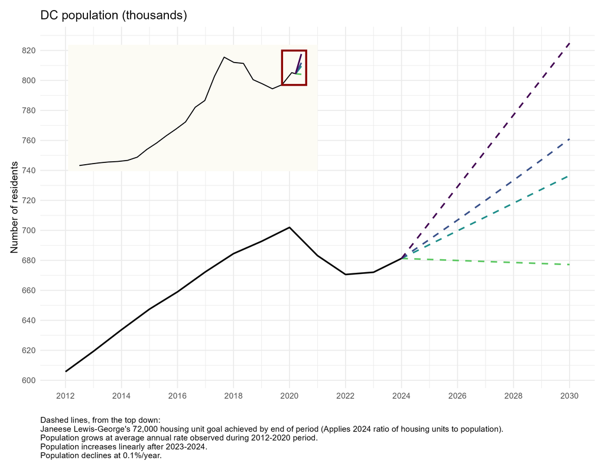

The chart below shows the estimated number of each type of housing unit that are associated with each scenario.

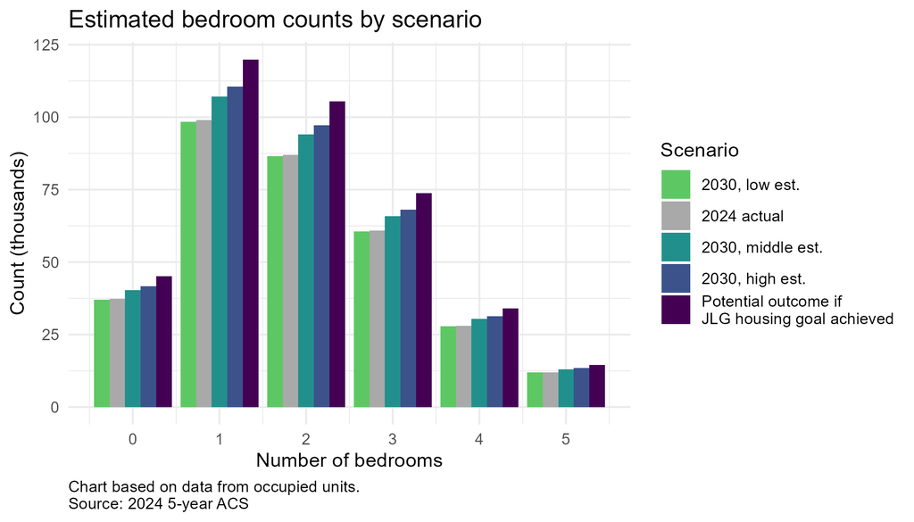

## Household size and dwelling unit statistics

The charts below show DC’s demographic and housing characteristics in the 2024 5-year ACS, weighted by individual person. Group quarters residents are not shown (their inclusion doesn’t change the charts much).

- A plurality of DC households are comprised of one person.
- Most DC residents rent.
- A plurality of DC residents live in row houses and duplexes.

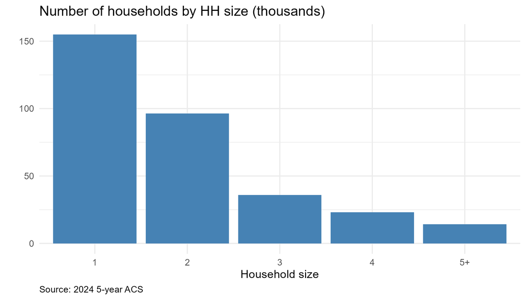

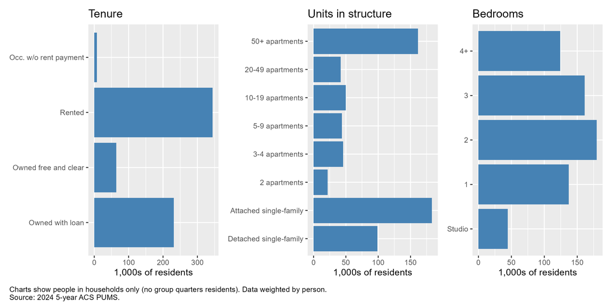

One-person households have grown slightly as a share of total households over time. Larger households have shrunk as a share of total households. Perhaps unsurprisingly, studios as a share of total units have grown over time; large households are also now more likely to live in smaller units (charts in the appendix).

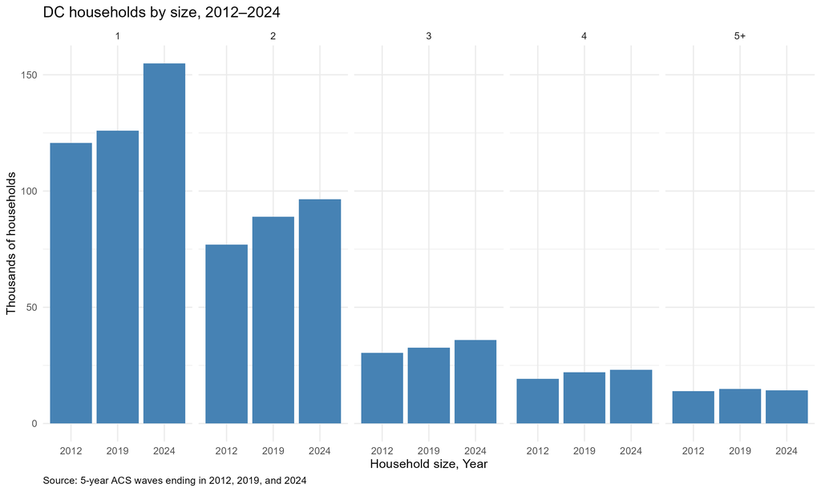

## Existing research

### [COG](https://www.mwcog.org/documents/2019/09/10/the-future-of-housing-in-greater-washington/) (2019)

**DMV-wide, ~320,000** units needed to house the projected number of workers the COG expects the region will “need” in 2030.

Here’s their math:

- COG says the DMV will have 3.774 million jobs by 2030.
- COG says that the ideal “jobs per household ratio” is 1.54.
- $\frac{3,774,000 jobs}{1.54 jobs / household} =$ 2,450,000 households “needed”
- COG says that the DMV will have ~2.375 million households by 2030 under their baseline scenario.
- 2,450,000 - 2,375,000 = 75,000 household / housing unit shortfall.
- COG says there are 2,130,000 housing units now; to reach the 2,450,000 target, the DMV needs to build a total of 320,000 housing units.

The people at COG are smarter than me, so maybe this estimate is spot on, but it feels a little dicey to project housing need in a decade like this. It’s also sensitive to your assumptions: If you change the target jobs/households ratio to 1.5, the shortfall doubles; change the ratio to 1.6 and the method would suggest we have a housing surplus. Same goes for COG’s jobs & housing projections. (The National Association of Realtors actually does something similar to COG, but using a ratio of 2, and, of course, find that [the DMV has no housing shortage](https://www.nar.realtor/research-and-statistics/housing-statistics/housing-shortage-tracker).)

Maybe they just needed a number they could all agree on. In which case: makes sense! But projecting the number of jobs, housing, and housing demand 10 years from now feels a little quixotic. Many of these estimates feel this way. I understand that COG is a transportation planning organization, so they may need some rough estimate of these trends for their own purposes.

Final note: the COG isn’t maximizing welfare or productivity in this paper. They’re not estimating how many people would like to live in the DMV, if given the opportunity. They’re estimating the number of houses needed in the DMV to reduce in-commuting from surrounding counties.

## [Freddie Mac](https://www.freddiemac.com/research/insight/20200227-the-housing-supply-shortage) (2020)

DC **~34,000** units short

- Calculates housing demand as $\frac{h}{1-v}$, where
  - $h$ is the number of target households, or, “the number of unconstrained households that would have formed if households did not face any constraints related to housing costs.”
  - $v$ is the “long-term vacancy rate.” They say $v$ is 13%, based on data from 1970-2000 (they are claiming that housing supply was not constrained before 2000; as another paper discusses below, this is not exactly true).
- Then they compare that demand to actual housing supply in the states and DC, accounting for interstate migration.
- They find DC’s housing shortage is almost 10% of its existing supply, or about 34,000 units.

[AEI](https://heat.aeihousingcenter.org/toolkit/housing_shortage) (2025)

DC **32,149** units short

### [Up For Growth](https://upforgrowth.org/apply-the-vision/housing-underproduction-reports/) (2025)

DC **~16,600** units short

They use this formula:

$Housing Underproduction = (Households + MissingHouseholds)*1.05 - (TotalHousingUnits - 2ndHomes - UninhabitableHomes)$

Where 1.05 represents the 5% target vacancy rate.

This approach provides the lowest end estimate. A big reason why is because it doesn’t account for equilibrium effects. The “missing households” term accounts for households in DC that are living in overcrowded conditions, forming 1 household when the inhabitants would rather be 3 households. But it doesn’t account for households that just live in PG or MoCo counties, rather than DC, because DC rents are higher. This is obviously a large portion of the true demand to live in DC.

### [Kevin Corinth & Hugo Dante](https://docs.iza.org/dp15447.pdf) (2022)

DC **~116,212** units short

These authors estimate how many units would be built in the “absence of supply constraints and the actual number of homes.” In other words, how many homes people would build, if the economic rent associated with providing housing approached zero? This is closer to what economists hear when someone says “there’s a housing shortage.”

They find DC has a 116,212 unit shortage. This is likely an over-estimate, because it doesn’t account for equilibrium effects. For example: if Arlington suddenly built a bunch more housing units, more people would move to and live in Arlington. This would ease housing demand in DC proper and slow rent increases. But the authors calculate separate housing shortages by state, so they don’t capture this equilibrium dynamic. It might make sense to think of this estimate as an upper bound on how much market rate housing would get built if costs fell to the lower end of the national average.

(On the other hand, agglomeration effects might make a more populous DC more attractive to people looking to move. Which would increase demand.)

### [Moodys](https://www.policymap.com/data/moodys-housing-shortfall?) (2025)

This project estimates housing shortages by Census tract. I’m trying to get access.

### Filtering estimate

Another way to think about housing demand is in terms of housing affordability. We can use estimates from [Mast (2023)](https://research.upjohn.org/cgi/viewcontent.cgi?article=1012&context=up_policybriefs) to think about the number of new units that would need to be constructed, in order to create moving opportunities for households below 100% of AMI, but above 50% of AMI. Here’s some quick math:

- As of the 2018-2022 5-year ACS, there were ~14,700 DC renter households between 50% and 100% of AMI who were rent-burdened (paying more than 30% of their income in rent).
- Mast finds that constructing 100 new market rate units leads 45-70 households in cheaper units to leave those units and start renting in the new units. This opens up those 45-70 cheaper units for more moderate-income people to rent.
- To create moving chains that would allow DC households at 50-100% AMI to move to cheaper units, you might need to build **21,000–33,000** new market-rate units.
- Renters below 50% AMI wouldn’t benefit as much, especially in the short run, because their incomes are low enough that more market-rate housing doesn’t necessarily create moving-chain opportunities for them.

## Next steps

The main challenge with estimating housing demand is that we don’t directly observe demand. We see how many people choose to live in DC, and what they pay to rent or buy a home. But those decisions are influenced by the amount of housing available.

In other words, we don’t see this complete picture:

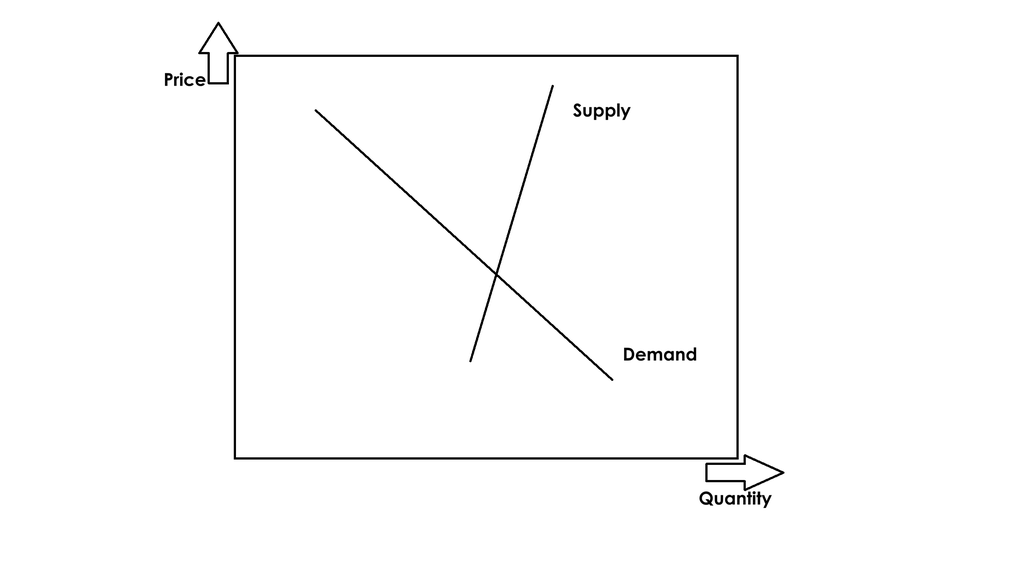

We only see a series of equilibrium points, where those two curves meet, over time.

To trace out the demand curve, we really need an exogenous shock that shifts supply, but does not influence demand:

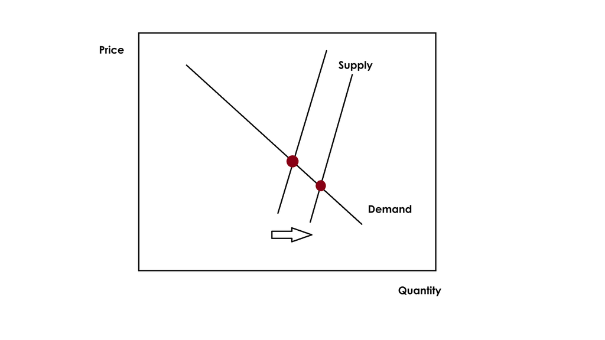

These kinds of shocks are hard to come by. It’s not clear that DC has had any discrete jumps in housing supply during a period in which there were not confounding changes in demand.

This also raises normative questions. The true economic “demand for housing in DC” is likely something closer to the Corinth & Dante estimate: over 100,000 units. That is how many people would live in DC if the economic rents associated with being a developer, landlord, etc. were ~zero. But meeting that demand would mean DC would get much denser. It’s not clear that existing DC residents want that, and they vote for the people that make these decisions.

So we’re left with a question: not “what does it mean to meet the demand for housing in DC” but **“How much of the demand for housing in DC do we want to meet?”**

Next steps:

- Clarify specific research questions.
- Replicate [this Brookings paper](https://www.brookings.edu/articles/make-it-count-measuring-our-housing-supply-shortage/) that uses the [Kitagawa–Oaxaca–Blinder decomposition](https://en.wikipedia.org/wiki/Kitagawa%E2%80%93Oaxaca%E2%80%93Blinder_decomposition) to estimate a national housing supply shortage, but for DC specifically.
- do some what ifs with permitting costs?

## Appendix charts

**Click to show/hide additional charts**

Below is a cross-tabulation of household size and unit size in the 2024 5-year ACS data.

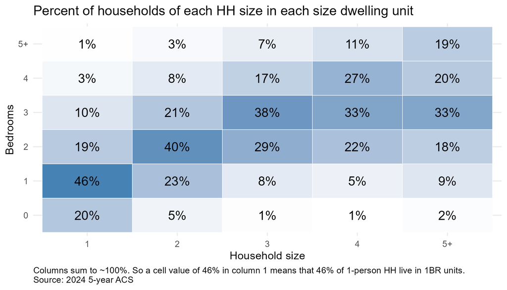

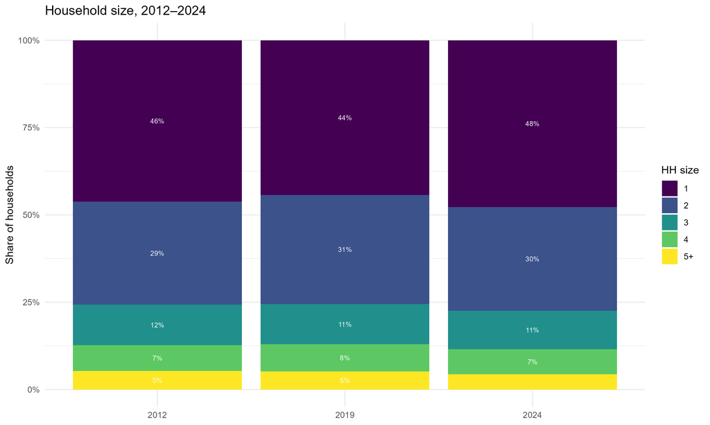

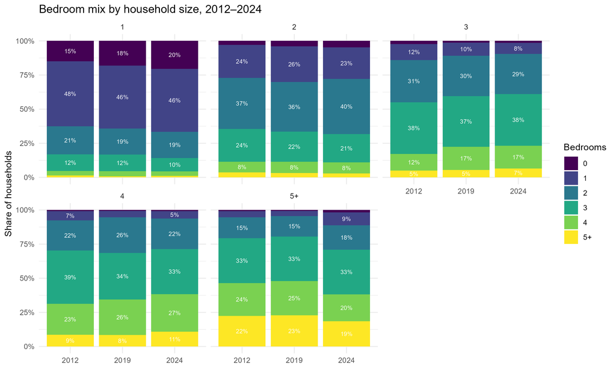